# Bayesian Inference for the Normal Mean (Ch.11)

AG Schissler

3/2/2020

## Start-of-class work:

## 11.1 Bayes’ Theorem for Normal Mean with a Discrete Prior

### Let’s revisit Exercise 11.2

- Convince me that one could evaluate the normal density at standardized $z$ values or the original data $y$.
- How does the calculation change?
- Why is the posterior the same?

```r
## let's do Exercise 11.2 using code
mu <- seq(160, 230, by = 10)
sigma <- 15
g_of_mu <- 1 / length(mu) ## equal weights
y <- c(175, 190, 215, 198, 184, 207, 210, 193, 196, 180)
n <- length(y)

## for one data point y_1
likelihood_y <- as.vector(sapply( y[1], dnorm, mean = mu, sd= sigma ))
z1 <- (y[1] - mu) / sigma
likelihood_z <- sapply( z1, dnorm)

## prior times likelihood
unnormalized_posterior_y <- g_of_mu * likelihood_y
unnormalized_posterior_z <- g_of_mu * likelihood_z

## marginal
marginal_y <- sum(unnormalized_posterior_y)
marginal_z <- sum(unnormalized_posterior_z)

## posterior
(posterior_y <- unnormalized_posterior_y / marginal_y)
```

```
## [1] 0.1767087986 0.2755991946 0.2755991946 0.1767087986 0.0726471590
## [6] 0.0191495832 0.0032365345 0.0003507369
```

```r
(posterior_z <- unnormalized_posterior_z / marginal_z)
```

```
## [1] 0.1767087986 0.2755991946 0.2755991946 0.1767087986 0.0726471590
## [6] 0.0191495832 0.0032365345 0.0003507369
```

```r
all.equal(posterior_y, posterior_z)
```

```
## [1] TRUE
```

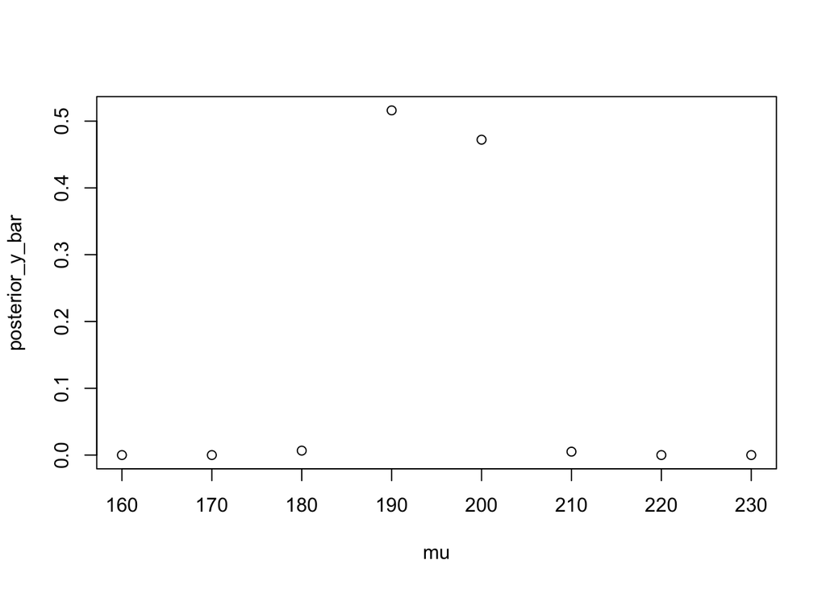

```r
## all observations at once using sufficient statistics (Equation 11.2)

## CAREFUL to put in the correct standard deviation = sqrt (sigma^2 / n)
likelihood_y_bar <- as.vector(sapply( mean(y), dnorm, mean = mu, sd= sigma/sqrt(n) ))

## prior times likelihood
unnormalized_posterior_y_bar <- g_of_mu * likelihood_y_bar

## marginal
marginal_y_bar <- sum(unnormalized_posterior_y_bar)

## posterior
posterior_y_bar <- unnormalized_posterior_y_bar / marginal_y_bar
plot(x = mu, y = posterior_y_bar)
```

## 11.2 Bayes’ Theorem for Normal Mean with a Continuous Prior

### To motivate these analyses let’s collect some data from the class

```r
sleep_times <- c(10, 8, 7, 9, 8, 7.5, 5, 6.5, 7.5, 6, 11, 7, 8, 8.33, 8.25, 10, 6, 7, 8.5,8, 9, 9, 8, 9.5, 8, 9, 8.11, 7)
mean(sleep_times)
```

```
## [1] 8.006786
```

```r
sd(sleep_times)
```

```
## [1] 1.325424
```

### Flat prior for $\mu$ (Jeffrey’s Prior for Normal Mean)

Since $g(\mu)=1$ everywhere on the real line the posterior $(\mu | y_1, \ldots, y_n) \sim Normal(\bar{y}, \sigma^2 / n)$.

### Normal prior

Let’s discuss the derivation of the updated (posterior) parameters for the normal mean $\mu$ under a conjugate (normal-normal) model.

Equation 11.4:

$$m^\prime = \frac{(\sigma^2 m + s^2 y)}{\sigma^2 + s^2} = \frac{\sigma^2}{\sigma^2 + s^2} \times m + \frac{s^2}{\sigma^2 + s^2} \times y$$

$$(s^\prime)^2 = \frac{\sigma^2 s^2}{\sigma^2 + s^2}$$

Or in terms of precision $1 / \sigma^2$:

By factoring out, we see that

$$m^\prime = \frac{1 / s^2}{1 / \sigma^2 + 1 / s^2} \times m + \frac{1 / \sigma^2}{1 / \sigma^2 + 1 / s^2} \times y$$

$$\frac{1}{(s^\prime)^2} = \left( \frac{\sigma^2 s^2}{\sigma^2 + s^2} \right)^{-1} = \frac{\sigma^2 + s^2}{\sigma^2 s^2} =\frac{1}{\sigma^2} + \frac{1}{s^2}$$

Let’s go back to the question whether the prior and observation variances “add” like do would with independent random variables. What do we say now?

### From a random sample $y_1, \ldots, y_n$

$$\frac{1}{(s^\prime)^2} = \frac{1}{s^2} + \frac{n}{\sigma^2}$$

$$m^\prime = \frac{1 / s^2}{n / \sigma^2 + 1 / s^2} \times m + \frac{n / \sigma^2}{n / \sigma^2 + 1 / s^2} \times \bar{y}$$

## 11.3 Choosing Your Normal Prior

Choose your prior mean $m$ and prior variance $s^2$ based on your prior beliefs about $E(\mu)$ and $Var(\mu)$. Remember that means are less variable than individual observations.

It is recommended to check your *equivalent sample size*: Set your prior variance $s^2 = \sigma^2 / n_{eq}$ and solve for $n_{eq}$.

```r
## 6 to 8 hours
m <- 7
s2 <- 1
## assume true sigma (or could estimate from data)
sigma2 <- 2
## then equivalent sample size in the prior specification is
(n_eq <- sigma2/s2)
```

```
## [1] 2
```

```r
## this is an importat ratio...
```

## now let’s compute the posterior under some of your priors

```r
update_normnp <- function(m, s2, n, y_bar, sigma2){
    ## posterior precision is the sum of prior and sample precision
    total_precision <- 1/s2 + n/sigma2
    s_prime2 <- 1/total_precision
    ## posterior mean is the weighted average of prior and sample mean
    m_prime <- ( (1/s2) / total_precision ) * m + ( (n/sigma2) / total_precision ) * y_bar
    ## return as a list
    list(m_prime=m_prime, s_prime2=s_prime2, s_prime = sqrt(s_prime2))
}

y_bar <- mean(sleep_times)
n <- length(sleep_times)
sigma2 <- 1
s2 <- 1
m <- 7

update_normnp(m = m, s2 = s2, n = n, y_bar = y_bar, sigma2 = sigma2)
```

```
## $m_prime
## [1] 7.972069
##
## $s_prime2
## [1] 0.03448276
##
## $s_prime
## [1] 0.1856953
```

```
## Known standard deviation :1
## Posterior mean           : 7.972069
## Posterior std. deviation : 0.1856953
```

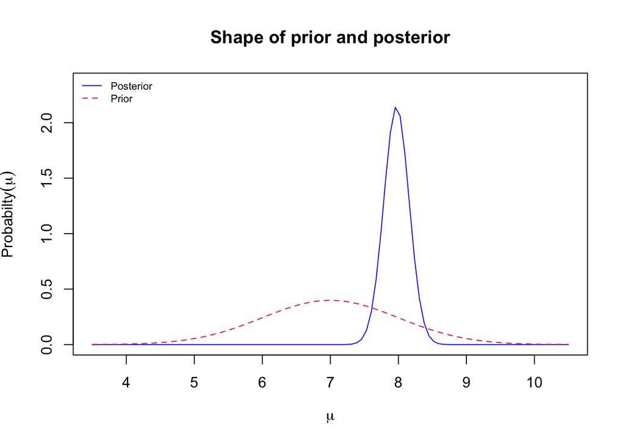

```
##
## Prob.    Quantile
## ------   ----------
## 0.005     7.4937495
## 0.010     7.5400770
## 0.025     7.6081128
## 0.050     7.6666273
## 0.500     7.9720690
## 0.950     8.2775106
## 0.975     8.3360251
## 0.990     8.4040609
## 0.995     8.4503885
```

```r
Bolstad::normnp(x = sleep_times, m.x = m, s.x = sqrt(s2), sigma.x = sqrt(sigma2), plot = TRUE)
```

## 11.4 Bayesian Credible Interval for Normal Mean

### Known variance

```r
posterior <- update_normnp(m = m, s2 = s2, n = n, y_bar = y_bar, sigma2 = sigma2)

## 89% credible Interval
alpha = 0.11
z_alpha_over_2 <- qnorm(p = 1 - alpha/2)

(lower <-  posterior$m_prime - z_alpha_over_2* posterior$s_prime)
```

```
## [1] 7.675292
```

```r
(upper  <-  posterior$m_prime + z_alpha_over_2* posterior$s_prime)
```

```
## [1] 8.268846
```

### Unknown variance

```r
## use the sample variance estimated for sigma2
sigma2 <- var(sleep_times)
posterior <- update_normnp(m = m, s2 = s2, n = n, y_bar = y_bar, sigma2 = sigma2)

## 89% credible Interval
alpha = 0.11
## additional uncertainty
t_alpha_over_2 <- qt(p = 1 - alpha/2, df = n - 1)

(lower <-  posterior$m_prime - t_alpha_over_2* posterior$s_prime)
```

```
## [1] 7.545812
```

```r
(upper  <-  posterior$m_prime + t_alpha_over_2* posterior$s_prime)
```

```
## [1] 8.348884
```

## 11.5 Predictive Density for Next Observation

- The predictive distribution of the next observation $y_{n+1}$ is normal$(m^\prime, (s^\prime)^2)$ where the mean $m^\prime = m_n$, the posterior mean, and, the observation variance plus the posterior variance. (The posterior variance allows for the uncertainty in estimating $\mu$.) The predictive (posterior) distribution is found by marginalizing $\mu$ out of the joint distribution $f(y_{n+1}, \mu | y_1, \ldots, y_n)$.
- Let’s discuss the derivation of Equation 11.9. It is a beastly bit of algebra. Keep the goal in mind and be thankful you don’t have to do this since someone already did.

```r
## predictive distribution
compute_normnp_predictive <- function(m, s2, n, y_bar, sigma2){
    posterior_params <- update_normnp(m = m, s2 = s2, n = n, y_bar = y_bar, sigma2 = sigma2)
    ## return as a list
    list(m_nplus1 = posterior_params$m_prime, s_nplus1_2= sigma2 + posterior_params$s_prime2)
}

## compare
update_normnp(m = 7, s2 = 1, n = n, y_bar = y_bar, sigma2 = 1)
```

```
## $m_prime
## [1] 7.972069
##
## $s_prime2
## [1] 0.03448276
##
## $s_prime
## [1] 0.1856953
```

```r
compute_normnp_predictive(m = m, s2 = 1, n = n, y_bar = y_bar, sigma2 = 1 )
```

```
## $m_nplus1
## [1] 7.972069
##
## $s_nplus1_2
## [1] 1.034483
```

## Practice today’s concepts on HW 7 Ch. 11 Exercise 5

## Closing

What is the difference between the *posterior* and the *predictive posterior*?